# Exercise 2 - Data Preparation

Ryan Wesslen

Sept 27, 2016

### Objective: Analyze the major presidential candidates Tweets

Our goal is to analyze the rhetoric (if you can call it that) of the Tweets for four major political candidates for president: Hillary Clinton, Bernie Sanders, Donald Trump and Ted Cruz.

As we mentioned in yesterday’s session, there are two ways to run this RMarkdown file: as automatically as a Knit (e.g. to produce a HTML file) or in manually chunks.

If you run it in chunks (as we will in this tutorial), you will need to set your working directory and remove one of the “.” from the `read.csv()` and `source()` functions. If you are running it as Knit file, you can leave as is.

#### Step 1: Read in the data.

Like yesterday, our first steps include setting our working directory (if running as chunks) and loading in our dataset.

```r
#set your personal working directory if you're running as chunks
#setwd("~/Dropbox/fall-2016-pm-twitter-text/")

#remove one of the "." if you are running as chunks
raw.tweets <- read.csv("../datasets/pres-tweets.csv", stringsAsFactors = F)
source('../functions.R')
```

#### Step 2: Explore the dataset.

Let’s explore our dataset. You can either open the dataset or run the `str()` function.

```r
str(raw.tweets)
```

```
## 'data.frame':    19103 obs. of  8 variables:
##  $ id                   : num  6.07e+17 6.07e+17 6.07e+17 6.07e+17 6.07e+17 ...
##  $ estTime              : chr  "2015-06-04 18:06:04" "2015-06-04 17:47:32" "2015-06-04 17:44:17" "2015-06-04 17:41:33" ...
##  $ displayName          : chr  "Ted Cruz" "Donald J. Trump" "Donald J. Trump" "Hillary Clinton" ...
##  $ body                 : chr  "I think what Republican primary voters are looking for is trust. https://t.co/Tw4lkrRxO3 #ATimeForTruth #MakeDCListen" "With great patriots in Mason City who also want to bring the American Dream back! We can Make America Great Again! http://t.co/"| __truncated__ "…
##  $ favoritesCount       : int  159 174 95 922 67 143 519 15 948 568 ...
##  $ retweetCount         : int  164 81 41 677 31 155 478 8 776 290 ...
##  $ generator.displayName: chr  "TweetDeck" "Twitter Web Client" "Instagram" "TweetDeck" ...
##  $ link                 : chr  "http://twitter.com/tedcruz/statuses/606597817998712832" "http://twitter.com/realDonaldTrump/statuses/606593154729525248" "http://twitter.com/realDonaldTrump/statuses/606592335061897216" "http://twitter.com/HillaryClinton/statuses/606591647271387136" ...
```

We have 19,103 Tweets, averaging about 4-5k Tweets per candidate.

#### Step 3: Explore the data

We’ll use the `dplyr` package to explore aggregate counts in the dataset.

```r
library(dplyr)

agg_tweets <- raw.tweets %>%
  group_by(displayName) %>%
  summarise(Count = n()) %>%
  arrange(desc(Count))

agg_tweets
```

```
## # A tibble: 4 × 2
##       displayName Count
##             <chr> <int>
## 1 Donald J. Trump  6402
## 2  Bernie Sanders  4844
## 3 Hillary Clinton  4236
## 4        Ted Cruz  3621
```

Further, let’s first plot the Tweet count per candidate by day.

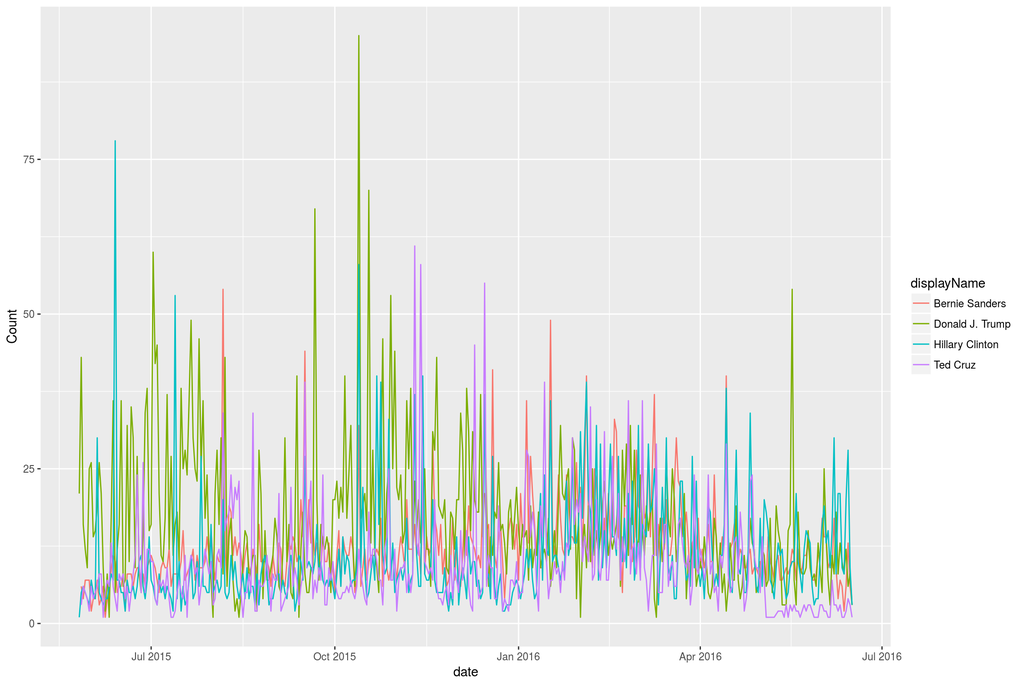

```r
library(ggplot2)

raw.tweets$date <- as.Date(raw.tweets$estTime, "%Y-%m-%d")
date_tweets <- raw.tweets %>%
  group_by(date, displayName) %>%
  summarise(Count = n())

ggplot(date_tweets, aes(date, Count, colour = displayName, group = displayName)) +
  geom_line()
```

Unfortunately this is a bit noisy. Let’s instead go with month. We’ll use the `zoo` package to extract the year-month for all Tweets.

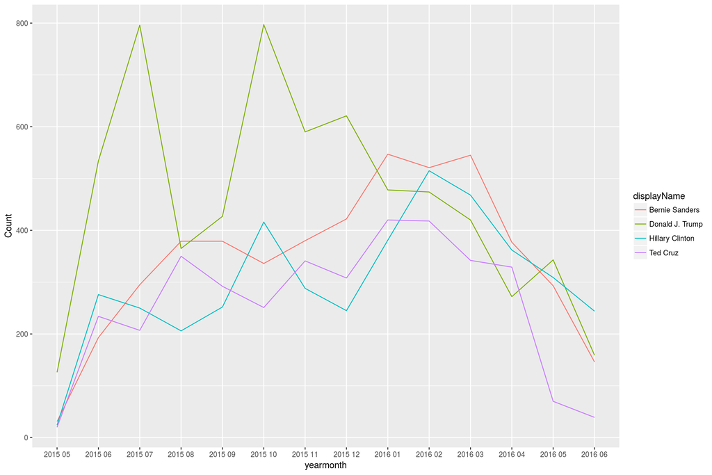

```r
temp <- zoo::as.yearmon(raw.tweets$date)

raw.tweets$yearmonth <- paste(format(temp, "%Y"),format(temp, "%m"))

date_tweets <- raw.tweets %>%
  group_by(yearmonth, displayName) %>%
  summarise(Count = n())

ggplot(date_tweets, aes(yearmonth, Count, colour = displayName, group = displayName)) +
  geom_line()
```

This is much clearer that Donald Trump is the heaviest Tweeter, with the largest number of Tweets in July 2015 and Oct 2015 with nearly **800 Tweets** per month or about 27 Tweets per day!

#### Step 4: Identify the most common Hashtags and Handles

Find the most common hashtags with the function `getCommonHashtags()`. Like the `timePlot()` function, this function is in the functions.R file.

For the function, use the Tweet text (body) as the input.

```r
hashtags <- getCommonHashtags(raw.tweets$body)

head(hashtags, 25)
```

```
## hashtags
##                #CruzCrew               #Trump2016   #MakeAmericaGreatAgain
##                      553                      525                      460
##               #DemDebate               #GOPDebate              #ChooseCruz
##                      350                      317                      171
##             #CruzCountry               #GOPdebate        #DebateWithBernie
##                      148                      138                      125
##           #CaucusForCruz             #DemTownHall          #CruzinToCaucus
##                       90                       86                       84
##           #CruzToVictory        #WashingtonCartel                #IACaucus
##                       83                       82                       69
##              #Bernie2016          #Trump2016https #DefundPlannedParenthood
##                       64                       63                       62
##             #Hillary2016              #nhpolitics
##                       62                       62
```

What are the top 25 hashtags? Which are Panther related?

Repeat the same exercise but with the function `getCommonHandles()` to find the most common handles.

```r
handles <- getCommonHandles(raw.tweets$body)

head(handles, 25)
```

```
## handles
## @realDonaldTrump         @FoxNews             @CNN      @megynkelly
##             1810              289              204              121
##         @JebBush           @POTUS  @HillaryClinton     @seanhannity
##               93               85               84               81
##   @foxandfriends   @oreillyfactor         @nytimes         @tedcruz
##               74               68               55               54
##           @Macys     @Morning_Joe        @KarlRove           @greta
##               53               46               43               39
##      @AnnCoulter             @GOP   @marklevinshow       @glennbeck
##               36               35               32               31
```

#### Step 5: Favorite and Retweet Count

This data also includes the number of times each Tweet was favorited (liked) and retweeted. This is a measurement of the response on social media by all users.

Let’s first explore the distribution of Favorited by each candidate using a box and whisker plot.

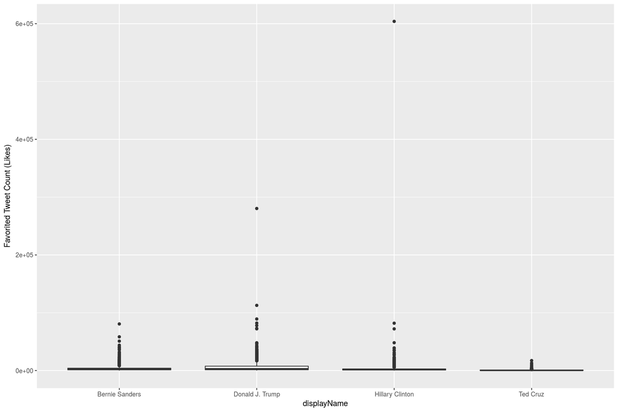

```r
library(ggplot2)
ggplot(raw.tweets, aes(displayName, favoritesCount)) +
  geom_boxplot() +
  ylab("Favorited Tweet Count (Likes)")
```

Unfortunately, this is distorted because there’s a huge tail. Let’s use change the Y-axis to log-based.

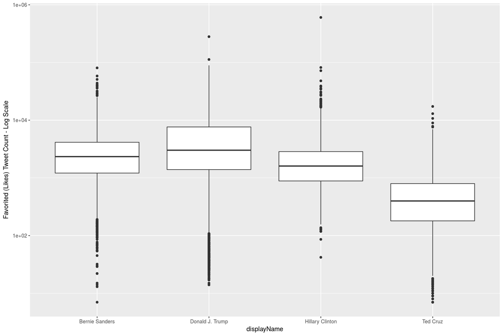

```r
ggplot(raw.tweets, aes(displayName, favoritesCount)) +
  geom_boxplot() +
  ylab("Favorited (Likes) Tweet Count - Log Scale") + scale_y_log10()
```

Ah - so we see that Donald Trump on average has a larger response than the other candidates during this period. Interestingly, Bernie has (on average) the second most number Tweets per candidate.

Let’s also plot the number of Retweets.

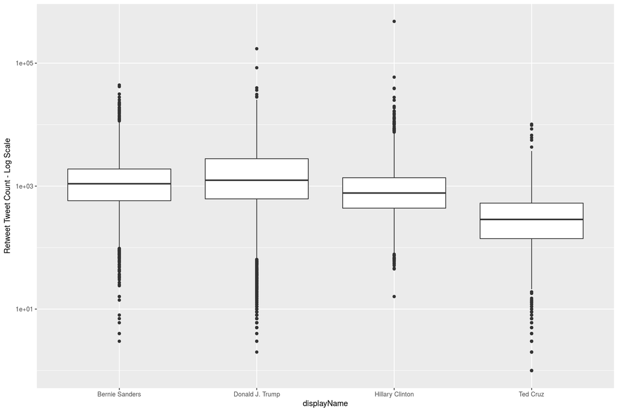

```r
ggplot(raw.tweets, aes(displayName, retweetCount)) +
  geom_boxplot() +
  ylab("Retweet Tweet Count - Log Scale") + scale_y_log10()
```

If we want to get the actual summary statistics, we can use the `psych` package:

```r
library(psych)
describeBy(raw.tweets$favoritesCount, group = raw.tweets$displayName)
```

```
##
##  Descriptive statistics by group
## group: Bernie Sanders
##    vars    n   mean      sd median trimmed     mad min   max range skew
## X1    1 4844 3310.1 3789.42 2338.5 2671.42 1911.81   7 80646 80639 5.78
##    kurtosis    se
## X1    68.11 54.45
## --------------------------------------------------------
## group: Donald J. Trump
##    vars    n    mean      sd median trimmed  mad min    max  range skew
## X1    1 6402 5711.06 7770.93   3019 4335.11 3387  14 280348 280334 9.21
##    kurtosis    se
## X1   256.95 97.12
## --------------------------------------------------------
## group: Hillary Clinton
##    vars    n    mean      sd median trimmed     mad min    max  range
## X1    1 4236 2609.82 9840.11   1605 1878.61 1259.47  42 604031 603989
##     skew kurtosis     se
## X1 54.24  3293.23 151.19
## --------------------------------------------------------
## group: Ted Cruz
##    vars    n   mean     sd median trimmed    mad min   max range skew
## X1    1 3621 610.92 763.46    398  483.61 382.51   0 17309 17309 6.96
##    kurtosis    se
## X1   102.64 12.69
```

```r
describeBy(raw.tweets$retweetCount, group = raw.tweets$displayName)
```

```
##
##  Descriptive statistics by group
## group: Bernie Sanders
##    vars    n    mean     sd median trimmed    mad min   max range skew
## X1    1 4844 1635.23 2190.5   1092 1253.25 879.92   3 44045 44042 6.93
##    kurtosis    se
## X1    84.14 31.47
## --------------------------------------------------------
## group: Donald J. Trump
##    vars    n   mean      sd median trimmed     mad min    max  range  skew
## X1    1 6402 2192.4 3524.24   1246 1662.61 1300.98   2 171707 171705 20.79
##    kurtosis    se
## X1   887.19 44.05
## --------------------------------------------------------
## group: Hillary Clinton
##    vars    n    mean      sd median trimmed    mad min    max  range  skew
## X1    1 4236 1337.58 7582.92    772  910.04 594.52  16 477978 477962 58.84
##    kurtosis     se
## X1  3683.39 116.51
## --------------------------------------------------------
## group: Ted Cruz
##    vars    n   mean     sd median trimmed    mad min   max range skew
## X1    1 3621 419.96 506.31    287  338.04 255.01   0 10176 10176  7.3
##    kurtosis   se
## X1    104.6 8.41
```

Let’s now get the top 10 Tweets for each candidate by the largest number of “Favorites”:

```r
candidates <- c("Bernie Sanders","Hillary Clinton","Donald J. Trump", "Ted Cruz")

for (i in 1:4){
  ctweets <- raw.tweets[raw.tweets$displayName == candidates[i],]
  row <- order(-ctweets$favoritesCount)
  print(candidates[i], row.names = FALSE)
  print(ctweets[row[1:10],c(4,2,5,7)], row.names = FALSE)
}
```

```
## [1] "Bernie Sanders"
##                                                                                                                                   body
##                                                                                                      Together. https://t.co/I8ca8foKTP
##                       America's first black president cannot and will not be succeeded by a hatemonger who refuses to condemn the KKK.
##                                              Game on. I look forward to debating Donald Trump in California before the June 7 primary.
##                              I got into politics not to figure out how to become President. I got into politics because I give a damn.
##   There is nothing I would like more than to take on and defeat Donald Trump, someone who must never become president of this country.
##  I want to thank Rahm Emanuel for not endorsing me. I don’t want the endorsement of a mayor shutting down schools and firing teachers.
##    The corporate media counted us out. The pollsters said we were way behind. But we won. Thank you, Michigan. https://t.co/Iywg9N3B1z
##           You still have time to run to your voting location before polls close. Get out and vote! #PrimaryDay https://t.co/e4k48x9Qth
##                                                           The political revolution wins in Indiana! Thank you. https://t.co/Ix7wutAw2g
##                                I am delighted that @realDonaldTrump has agreed to debate. Let’s do it in the biggest stadium possible.
##              estTime favoritesCount generator.displayName
##  2016-03-26 15:08:08          80646             TweetDeck
##  2016-02-28 14:17:10          58396    Twitter Web Client
##  2016-05-25 23:30:49          50920             TweetDeck
##  2015-12-11 15:42:06          43871             TweetDeck
##  2016-05-04 15:27:41          41332             TweetDeck
##  2016-03-11 21:35:51          39871             TweetDeck
##  2016-03-08 23:43:18          39003    Twitter Web Client
##  2016-06-07 18:07:12          38872    Twitter Web Client
##  2016-05-03 20:16:35          36585             TweetDeck
##  2016-05-26 14:29:13          36341    Twitter Web Client
## [1] "Hillary Clinton"
##                                                                                                                                         body
##                                                                                                 Delete your account. https://t.co/Oa92sncRQY
##                The boys are right. We need everyone's help to get the planet moving in the right direction. http://t.co/rNQSBSmgJ8 #action1D
##        To every little girl who dreams big: Yes, you can be anything you want—even president. Tonight is for you. -H https://t.co/jq7fKlfwGV
##                                                                                                                Proud. http://t.co/9J44PCYeuQ
##                                                                                                           #GOPdebate https://t.co/SGW200luN8
##                                                   Marriage equality is the law of the land. Deal with it. #GOPdebate https://t.co/gPS1BVgipl
##  Woke up to hear the devastating news from FL. As we wait for more information, my thoughts are with those affected by this horrific act. -H
##       For the first time in our history, a woman will be a major party’s nominee for President of the United States. https://t.co/4iLojpuPj8
##                                    How many more of these do we have to sit through? Asking for a friend. #GOPdebate https://t.co/AxGFlerSRW
##                    "I’m with her, I’m fired up, and I can’t wait to get out there and campaign for Hillary." —@POTUS https://t.co/ptbhfpCooQ
##              estTime favoritesCount generator.displayName
##  2016-06-09 13:27:53         604031             TweetDeck
##  2015-07-09 17:00:58          81943             TweetDeck
##  2016-06-07 20:08:58          72121             TweetDeck
##  2015-06-26 09:08:47          48100             TweetDeck
```

[output cut: 37 more lines]

```
##  Justice Scalia was an American hero. We owe it to him, &amp; the Nation, for the Senate to ensure that the next President names his replacement.
##        Over the past 13 months we built a movement. Make no mistake, that movement will continue: https://t.co/ZEb9WhGRSe https://t.co/o0ZSkCLy4X
##            Really sad. @realDonaldTrump you're better than this. We should all agree, racism is wrong, KKK is abhorrent.  https://t.co/dn2D74c5dl
##                                                        Thank you Iowa! This is OUR time. Join us: https://t.co/YBcXsTJlj4 https://t.co/hrHfyyo253
##              estTime favoritesCount generator.displayName
##  2016-03-23 23:30:49          17309    Twitter for iPhone
##  2016-03-22 21:21:33          12980    Twitter for iPhone
##  2016-03-17 22:18:49          10739      Twitter for iPad
##  2015-12-11 12:03:37           8964    Twitter for iPhone
##  2015-12-23 14:47:01           7835    Twitter for iPhone
##  2016-03-06 12:17:45           7608    Twitter Web Client
##  2016-02-13 17:27:29           6964    Twitter for iPhone
##  2016-05-05 16:15:49           6131    Twitter Web Client
##  2016-02-28 12:11:12           5214    Twitter for iPhone
##  2016-02-01 23:25:40           5162    Twitter for iPhone
```

```r
dev.off()
```

FYI - there are much better ways to display results than the `print` function. Consider using the `DT` or `gridExtra` for future tables.

Let’s combine our analysis from the time series plots and the Favorite counts to create plots for the candidates.

[figure not shown]

```r
#Bernie
ctweets <- raw.tweets[raw.tweets$displayName == "Bernie Sanders",]
ggplot(raw.tweets, aes(yearmonth, favoritesCount)) +
  geom_boxplot() +
  ggtitle("Bernie Sanders") +
  ylab("Favorited (Likes) Tweet Count - Log Scale") +
  scale_y_log10()
```

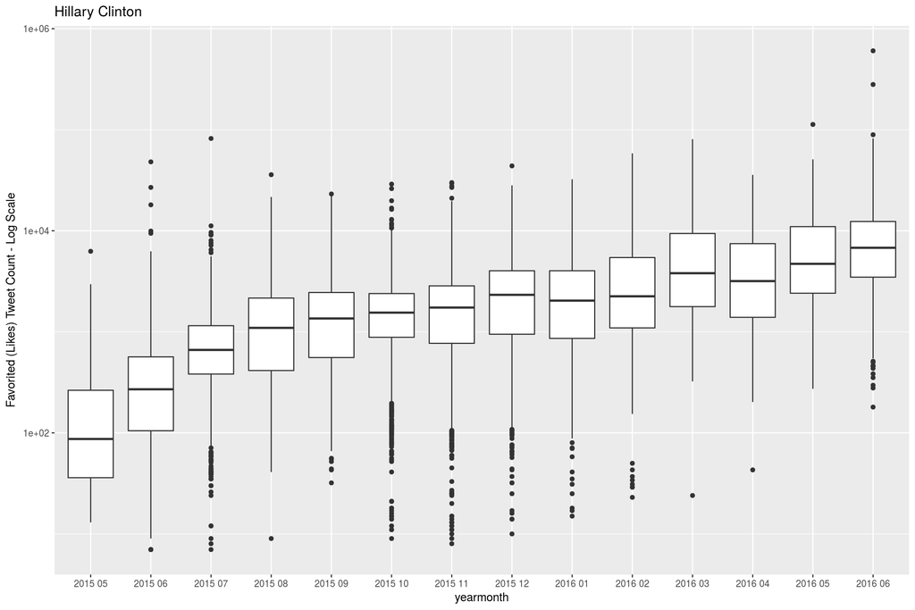

```r
#Hillary
ctweets <- raw.tweets[raw.tweets$displayName == "Hillary Clinton",]
ggplot(raw.tweets, aes(yearmonth, favoritesCount)) +
  geom_boxplot() +
  ggtitle("Hillary Clinton") +
  ylab("Favorited (Likes) Tweet Count - Log Scale") +
  scale_y_log10()
```

[figure not shown]

```r
#Trump
ctweets <- raw.tweets[raw.tweets$displayName == "Donald J. Trump",]
ggplot(raw.tweets, aes(yearmonth, favoritesCount)) +
  geom_boxplot() +
  ggtitle("Donald J. Trump") +
  ylab("Favorited (Likes) Tweet Count - Log Scale") +
  scale_y_log10()
```

[figure not shown]

```r
#Cruz
ctweets <- raw.tweets[raw.tweets$displayName == "Ted Cruz",]
ggplot(raw.tweets, aes(yearmonth, favoritesCount)) +
  geom_boxplot() +
  ggtitle("Ted Cruz") +
  ylab("Favorited (Likes) Tweet Count - Log Scale") +
  scale_y_log10()
```